# Modeling Tumor Size with Categorical Predictors

Sahil Sangani

2025-10-24

## 1 Introduction

This project investigates the relationship between lifestyle, demographic, and clinical factors in predicting tumor size using linear regression modeling in R. It demonstrates how categorical predictors—such as Physical Activity, Alcohol Consumption, and Smoking History—affect tumor growth and interact with one another.

The analysis is implemented in a templatized R Markdown framework, allowing users to easily substitute datasets or variable names to produce new analyses and visualizations with minimal adjustments. This modular design promotes fast exploratory analysis and reproducible research, enabling efficient iteration on different health-related or behavioral datasets.

The project includes statistical modeling, ANOVA testing, and visualization using ggplot2 to interpret variable effects and interactions.

## 2 Exploratory ANOVA Analysis

A two-way ANOVA was conducted to examine the effects of Physical Activity and Alcohol Consumption on Tumor Size mm. This analysis evaluates the individual (main) effects of each factor as well as their interaction effect—whether the influence of Physical Activity on Tumor Size mm depends on the level of Alcohol Consumption.

### 2.1 Main Effects and Interaction Results

Main Effect of Physical Activity

F(2, 9994) = 52.973, p = 0

The p-value indicates whether Physical Activity has a statistically significant effect on Tumor Size mm, ignoring the influence of Alcohol Consumption. At the 0.05 significance level, if p < 0.05, we reject the null hypothesis and conclude that Physical Activity has a significant effect on Tumor Size mm. Otherwise, there is no statistically significant effect.

Main Effect of Alcohol Consumption

F(1, 9994) = 736.991, p = 0

The p-value tests whether Alcohol Consumption significantly influences Tumor Size mm, controlling for Physical Activity. At the 0.05 significance level, if p < 0.05, we conclude that Alcohol Consumption has a significant effect on Tumor Size mm. Otherwise, we fail to reject the null hypothesis.

Interaction Effect: Physical Activity × Alcohol Consumption

F(2, 9994) = 3.21, p = 0.04

This tests whether the effect of Physical Activity on Tumor Size mm depends on the level of Alcohol Consumption. At the 0.05 significance level, if p < 0.05, we reject the null hypothesis and conclude that there is a statistically significant interaction between Physical Activity and Alcohol Consumption. Otherwise, there is no evidence of a significant interaction.

### 2.2 Visualizing ANOVA Results

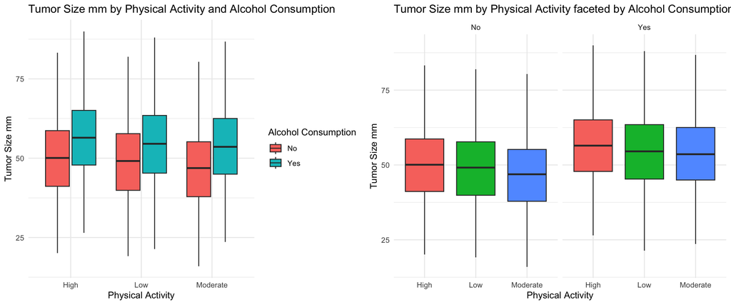

## 3 Linear Model with Two Categorical Predictors

A predictive model was fit using Physical Activity and Alcohol Consumption to predict Tumor Size mm.

```
## [1] "r-squared of the model:0.0778362028255499"
```

### 3.1 Model Summary

F(3, 4996) = 140.564, p = 0

R² = 0.0778

The F-statistic tests the null hypothesis that all regression coefficients are equal to zero, meaning the model with predictors does not explain more variability than a model with no predictors. At the 0.05 significance level, if p < 0.05, we reject the null hypothesis and conclude that the model provides a statistically significant improvement in explaining Tumor Size mm compared to a model with no predictors.

### 3.2 Goodness of Fit

The R-squared value of 0.0778 indicates that approximately 7.78% of the variability in Tumor Size mm is explained by the predictors Physical Activity and Alcohol Consumption.

### 3.3 Interpretation

If the model’s p-value is small (typically < 0.05), we can infer that at least one of the predictors (Physical Activity or Alcohol Consumption) has a statistically significant relationship with Tumor Size mm. To further understand the nature of these effects, we can examine the model’s coefficients and visualize predicted values or interaction plots.

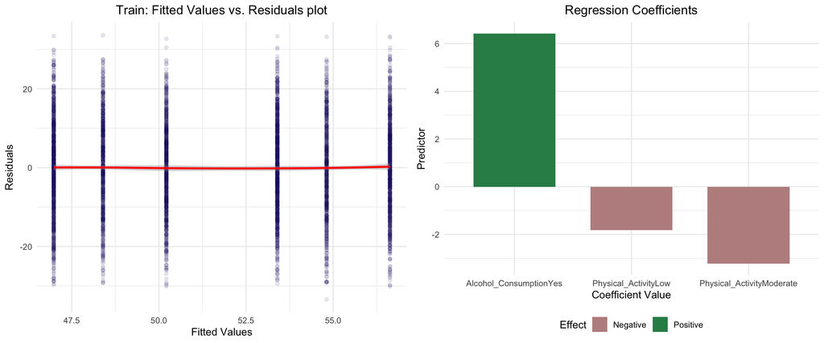

## 4 Assessing Variable Importance and Model Refinement

Joe is a 40 year old male, the following model is fit to figure out what change in lifestyle would reduce the risk of a bad outcome the most. I will fit the model with desired behavioral features, and then use test data which consists of a scenario, where Joe has a change in lifestyle in exactly one feature while the rest are held constant.

The model is first fitted using Joe’s baseline characteristics, and then evaluated under different lifestyle modifications. In each case, only one behavioral variable is changed at a time, while all others are held constant. This approach isolates the effect of each behavior on the predicted tumor size.

### 4.1 Predicted Outcomes for Different Lifestyle Scenarios

```
## [1] 56.74525 50.67246 50.31258 62.92355 55.23107
```

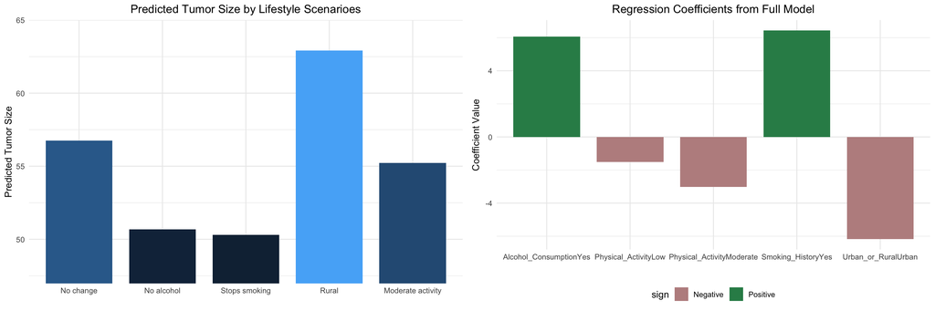

**Baseline scenario** – Joe drinks alcohol, smokes, lives in an urban area, and has low physical activity.

- Predicted tumor size: 56.75 mm

**Stops drinking alcohol** – Joe no longer drinks alcohol but continues to smoke and maintain low activity.

- Predicted tumor size: 50.67 mm
- Compared to baseline, quitting alcohol reduces his expected tumor size.

**Stops smoking** – Joe continues to drink alcohol but stops smoking.

- Predicted tumor size: 50.31 mm
- This yields the largest reduction in predicted tumor size among all lifestyle changes considered.

**Increases physical activity** – Joe remains a smoker and drinker but increases his physical activity level.

- Predicted tumor size: 55.23 mm
- Increased activity leads to a moderate decrease in tumor size relative to baseline.